# R Project - Identifying individuals most likely to click an ad

Geoffrey Chege

2022-03-18

## 1. Introduction

### 1.1 Defining the question

- Determine which individuals are most likely to click on an ad from the Exploratory Data Analysis

### 1.2 The Context

- A Kenyan entrepreneur has created an online cryptography course and would want to advertise it on her blog.
- She currently targets audiences originating from various countries.
- In the past, she ran ads to advertise a related course on the same blog and collected data in the process.
- She would now like to employ my services as a Data Science Consultant to help her identify which individuals are most likely to click on her ads.

### 1.3 Metric for success

- Clear indication of which individuals are likely to click on an ad i.e. Gender, location, income, daily internet usage.

### 1.4 Experimental Design Taken

- Installing packages and loading libraries needed
- Loading the data
- Data Cleaning
- Exploratory Data Analysis:
  - Univariate Analysis
  - Bivariate Analysis

### 1.5 Appropriateness of the available data

- The columns in the dataset include:
  - Daily_Time_Spent_on_Site
  - Age
  - Area_Income
  - Daily_Internet_Usage
  - Ad_Topic_Line
  - City
  - Male
  - Country
  - Timestamp
  - Clicked_on_Ad

## 2. Installing and loading Necessary Packages

## 3. Loading the Data

```r
ad <- read.csv("C:/Users/user/Downloads/advertising.csv")
head(ad)
```

```
##   Daily.Time.Spent.on.Site Age Area.Income Daily.Internet.Usage
## 1                    68.95  35    61833.90               256.09
## 2                    80.23  31    68441.85               193.77
## 3                    69.47  26    59785.94               236.50
## 4                    74.15  29    54806.18               245.89
## 5                    68.37  35    73889.99               225.58
## 6                    59.99  23    59761.56               226.74
##                           Ad.Topic.Line           City Male    Country
## 1    Cloned 5thgeneration orchestration    Wrightburgh    0    Tunisia
## 2    Monitored national standardization      West Jodi    1      Nauru
## 3      Organic bottom-line service-desk       Davidton    0 San Marino
## 4 Triple-buffered reciprocal time-frame West Terrifurt    1      Italy
## 5         Robust logistical utilization   South Manuel    0    Iceland
## 6       Sharable client-driven software      Jamieberg    1     Norway
##             Timestamp Clicked.on.Ad
## 1 2016-03-27 00:53:11             0
## 2 2016-04-04 01:39:02             0
## 3 2016-03-13 20:35:42             0
## 4 2016-01-10 02:31:19             0
## 5 2016-06-03 03:36:18             0
## 6 2016-05-19 14:30:17             0
```

## 4. Data Cleaning

### 4.1 Checking the attribute types

```
## Daily.Time.Spent.on.Site                      Age              Area.Income
##                "numeric"                "integer"                "numeric"
##     Daily.Internet.Usage            Ad.Topic.Line                     City
##                "numeric"              "character"              "character"
##                     Male                  Country                Timestamp
##                "integer"              "character"              "character"
##            Clicked.on.Ad
##                "integer"
```

### 4.2 converting time variable from character to date and time (POSIXct) format

```r
ad$Timestamp <- as.POSIXct(ad$Timestamp, "%Y-%m-%d %H:%M:%S",tz = "GMT")
```

### 4.3 Checking for duplicates

```r
duplicates <- ad[duplicated(ad),]

duplicates
```

```
##  [1] Daily.Time.Spent.on.Site Age                      Area.Income
##  [4] Daily.Internet.Usage     Ad.Topic.Line            City
##  [7] Male                     Country                  Timestamp
## [10] Clicked.on.Ad
## <0 rows> (or 0-length row.names)
```

There are no duplicates in the dataset

### 4.4 checking for null values

```r
colSums(is.na(ad))
```

```
## Daily.Time.Spent.on.Site                      Age              Area.Income
##                        0                        0                        0
##     Daily.Internet.Usage            Ad.Topic.Line                     City
##                        0                        0                        0
##                     Male                  Country                Timestamp
##                        0                        0                        0
##            Clicked.on.Ad
##                        0
```

There are no null values in the dataset

### 4.5 checking column names

```r
names(ad)
```

```
##  [1] "Daily.Time.Spent.on.Site" "Age"
##  [3] "Area.Income"              "Daily.Internet.Usage"
##  [5] "Ad.Topic.Line"            "City"
##  [7] "Male"                     "Country"
##  [9] "Timestamp"                "Clicked.on.Ad"
```

Replacing the periods “.” with underscores “_”

```r
names(ad) <- gsub("[.]", "_", names(ad))
```

```r
names(ad)
```

```
##  [1] "Daily_Time_Spent_on_Site" "Age"
##  [3] "Area_Income"              "Daily_Internet_Usage"
##  [5] "Ad_Topic_Line"            "City"
##  [7] "Male"                     "Country"
##  [9] "Timestamp"                "Clicked_on_Ad"
```

### 4.6 Outliers

I will use boxplots to check for outliers.

#### Boxplot for “Area_Income”

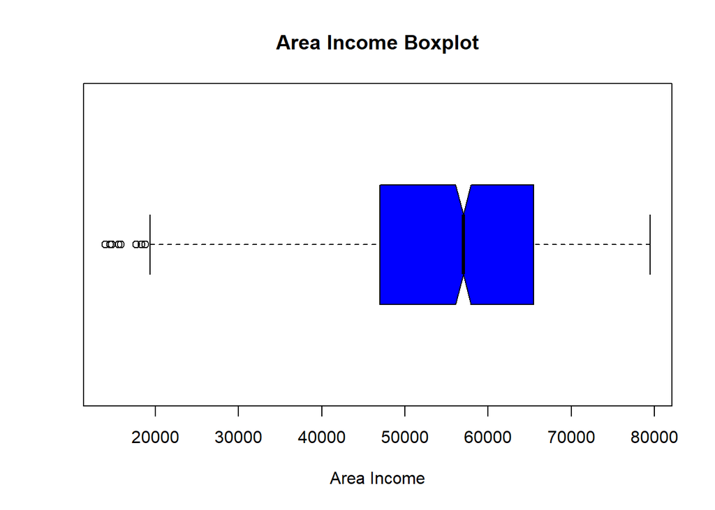

#### Boxplot for “Age”

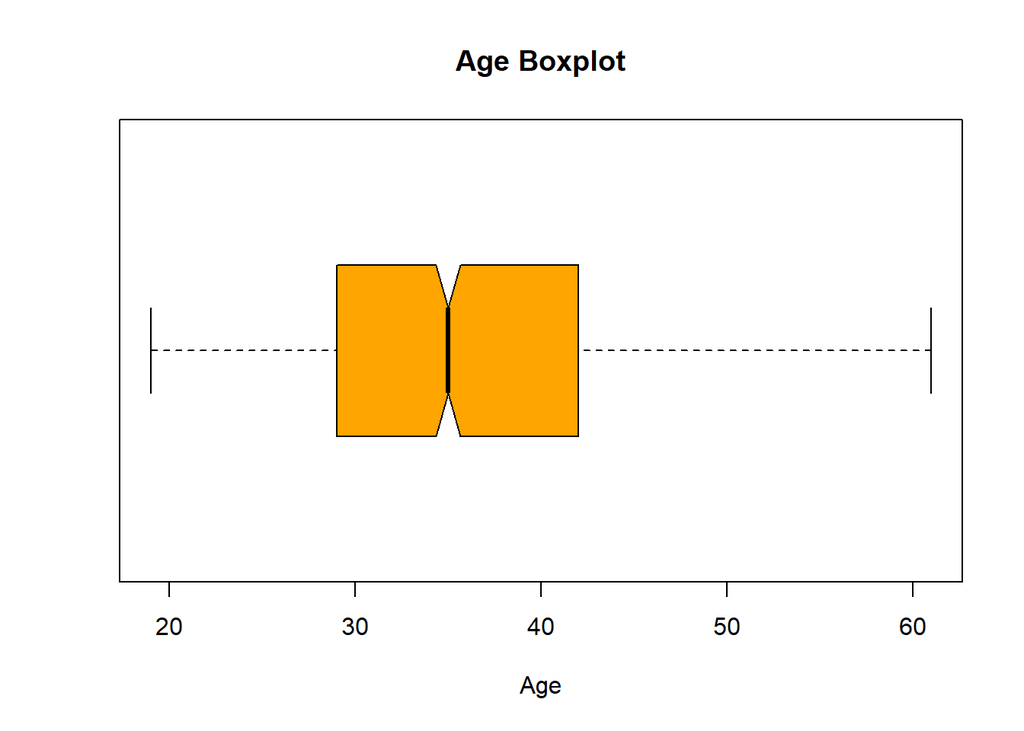

#### Boxplot for “Daily_Time_Spent_on_Site”

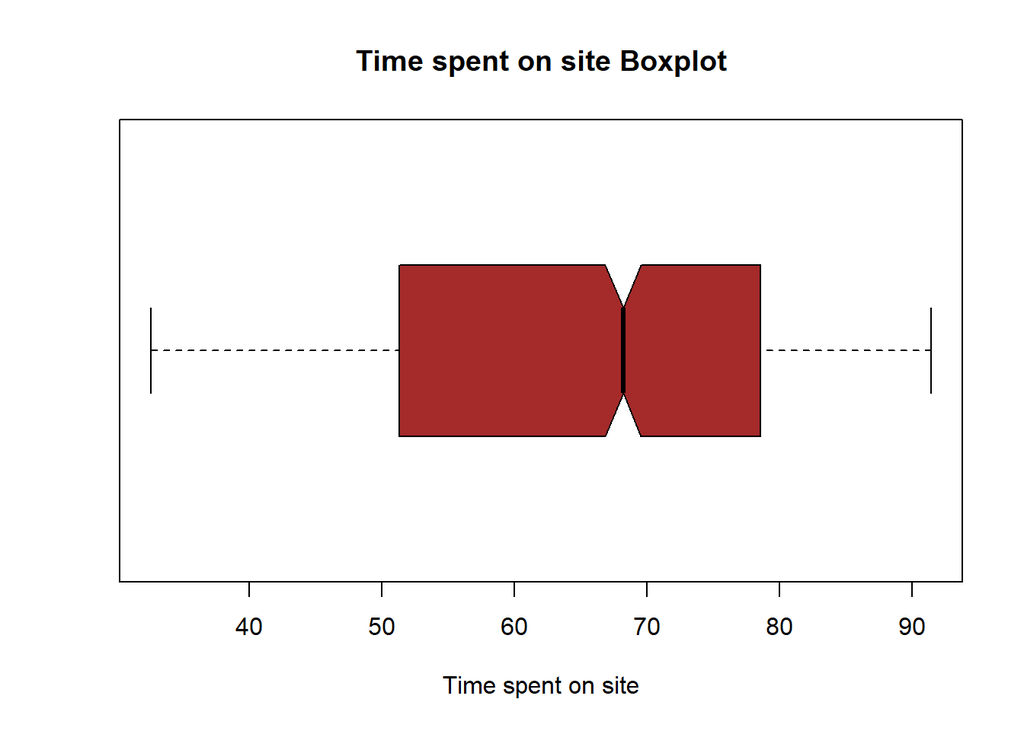

#### Boxplot for “Daily_Internet_Usage”

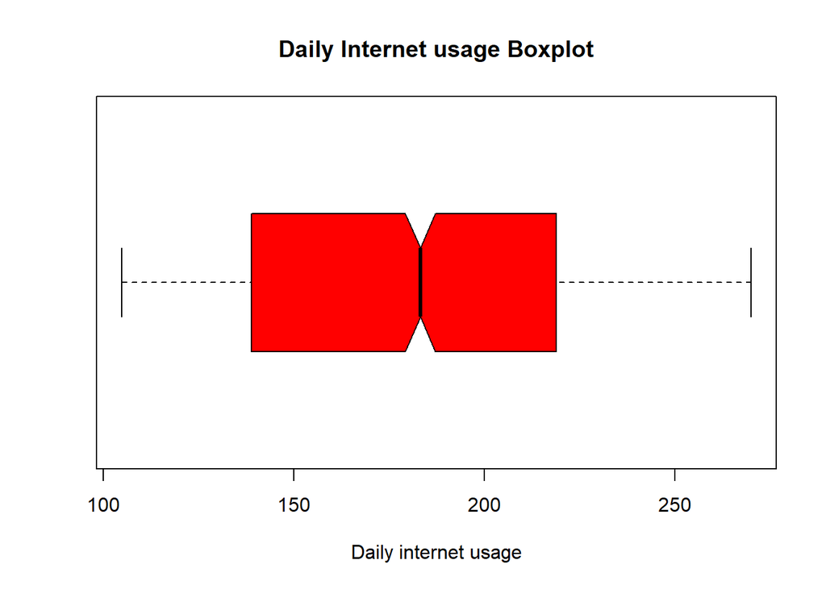

## 5. Exploratory Data Analysis

### 5.1 Univariate Analysis

Summary statistics of the dataset

```r
summary(ad)
```

```
##  Daily_Time_Spent_on_Site      Age         Area_Income    Daily_Internet_Usage
##  Min.   :32.60            Min.   :19.00   Min.   :13996   Min.   :104.8
##  1st Qu.:51.36            1st Qu.:29.00   1st Qu.:47032   1st Qu.:138.8
##  Median :68.22            Median :35.00   Median :57012   Median :183.1
##  Mean   :65.00            Mean   :36.01   Mean   :55000   Mean   :180.0
##  3rd Qu.:78.55            3rd Qu.:42.00   3rd Qu.:65471   3rd Qu.:218.8
##  Max.   :91.43            Max.   :61.00   Max.   :79485   Max.   :270.0
##  Ad_Topic_Line          City                Male         Country
##  Length:1000        Length:1000        Min.   :0.000   Length:1000
##  Class :character   Class :character   1st Qu.:0.000   Class :character
##  Mode  :character   Mode  :character   Median :0.000   Mode  :character
##                                        Mean   :0.481
##                                        3rd Qu.:1.000
##                                        Max.   :1.000
##    Timestamp                   Clicked_on_Ad
##  Min.   :2016-01-01 02:52:10   Min.   :0.0
##  1st Qu.:2016-02-18 02:55:42   1st Qu.:0.0
##  Median :2016-04-07 17:27:29   Median :0.5
##  Mean   :2016-04-10 10:34:06   Mean   :0.5
##  3rd Qu.:2016-05-31 03:18:14   3rd Qu.:1.0
##  Max.   :2016-07-24 00:22:16   Max.   :1.0
```

From the summary statistics, the following can be concluded about these columns:

#### Daily_Time_Spent_on_Site:

mean: 65

median: 68.22

#### Age:

mean: 36.01

median: 35

#### Area Income:

mean: 55,000

median: 57,012

#### Daily_Internet_Usage:

mean: 180

median: 183.1

Using describe() to get range, skewness, kurtosis and standard deviation among others:

```r
describe(ad)
```

```
##                          vars    n     mean       sd   median  trimmed      mad
## Daily_Time_Spent_on_Site    1 1000    65.00    15.85    68.22    65.74    17.92
## Age                         2 1000    36.01     8.79    35.00    35.51     8.90
## Area_Income                 3 1000 55000.00 13414.63 57012.30 56038.94 13316.62
## Daily_Internet_Usage        4 1000   180.00    43.90   183.13   179.99    58.61
## Ad_Topic_Line*              5 1000   500.50   288.82   500.50   500.50   370.65
## City*                       6 1000   487.32   279.31   485.50   487.51   356.57
## Male                        7 1000     0.48     0.50     0.00     0.48     0.00
## Country*                    8 1000   116.41    69.94   114.50   115.82    89.70
## Timestamp                   9 1000      NaN       NA       NA      NaN       NA
## Clicked_on_Ad              10 1000     0.50     0.50     0.50     0.50     0.74
##                               min      max    range  skew kurtosis     se
## Daily_Time_Spent_on_Site    32.60    91.43    58.83 -0.37    -1.10   0.50
## Age                         19.00    61.00    42.00  0.48    -0.41   0.28
## Area_Income              13996.50 79484.80 65488.30 -0.65    -0.11 424.21
## Daily_Internet_Usage       104.78   269.96   165.18 -0.03    -1.28   1.39
## Ad_Topic_Line*               1.00  1000.00   999.00  0.00    -1.20   9.13
## City*                        1.00   969.00   968.00  0.00    -1.19   8.83
## Male                         0.00     1.00     1.00  0.08    -2.00   0.02
## Country*                     1.00   237.00   236.00  0.08    -1.23   2.21
## Timestamp                     Inf     -Inf     -Inf    NA       NA     NA
## Clicked_on_Ad                0.00     1.00     1.00  0.00    -2.00   0.02
```

#### Mode

A function to determine the mode:

```r
mode <- function(v){
  uniq <- unique(v)
  uniq[which.max(tabulate(match(v,uniq)))]
}
```

The most recurrent Ad Topic Line:

```
## [1] "Cloned 5thgeneration orchestration"
```

The most recurrent City:

```
## [1] "Lisamouth"
```

The most recurrent Country:

```
## [1] "Czech Republic"
```

Checking the modal age using a barplot:

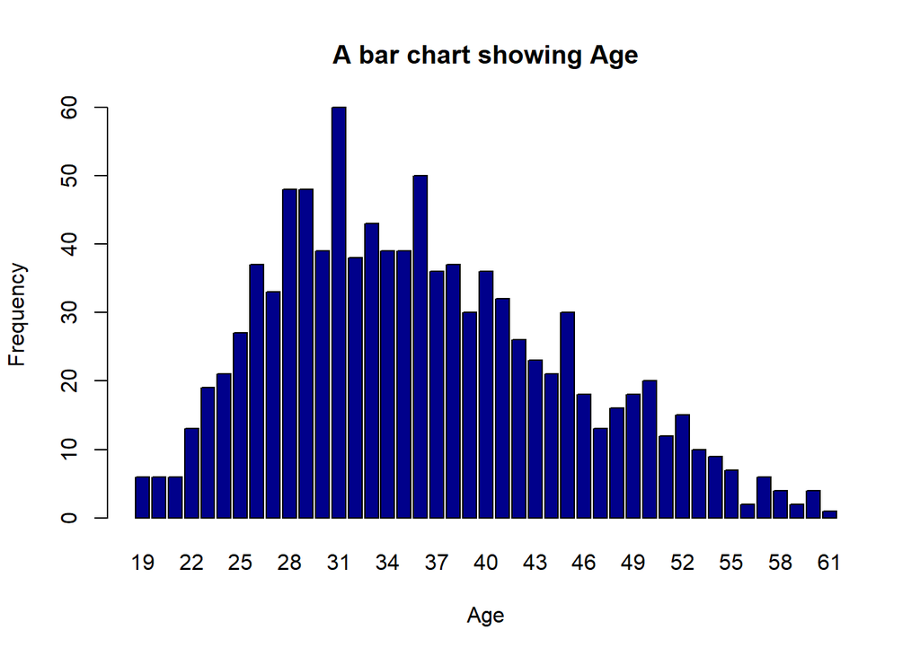

From the plot, the modal age is 31.

Checking the distribution in terms of gender where 1 is Male and 0 is Female:

```
## gender
##   0   1
## 519 481
```

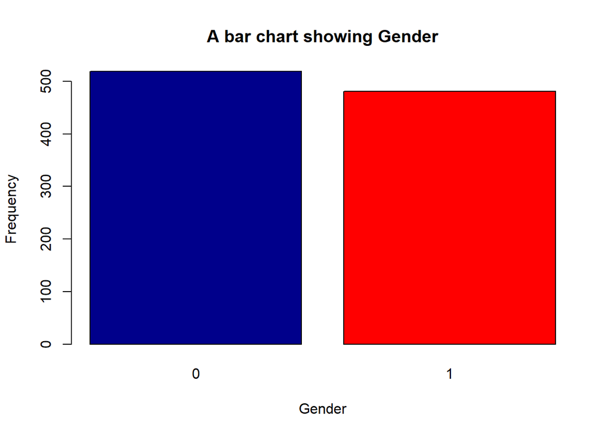

From this, there are More women than men, making female the modal gender.

### 5.2 Bivariate Analysis

#### Scatterplots

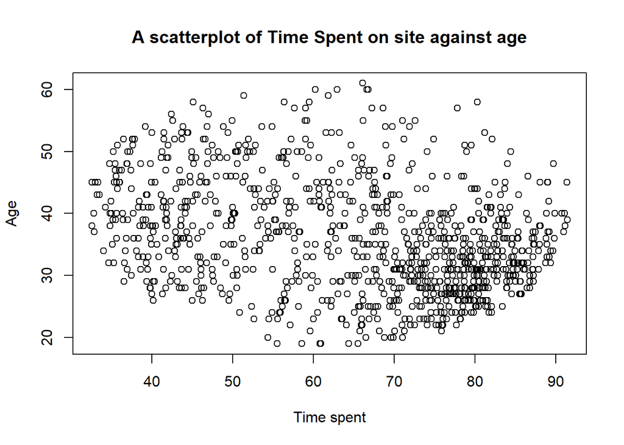

```r
# scatterplot
plot((ad$Daily_Time_Spent_on_Site), (ad$Age),
     main = "A scatterplot of Time Spent on site against age",
     xlab = 'Time spent',
     ylab = 'Age')
```

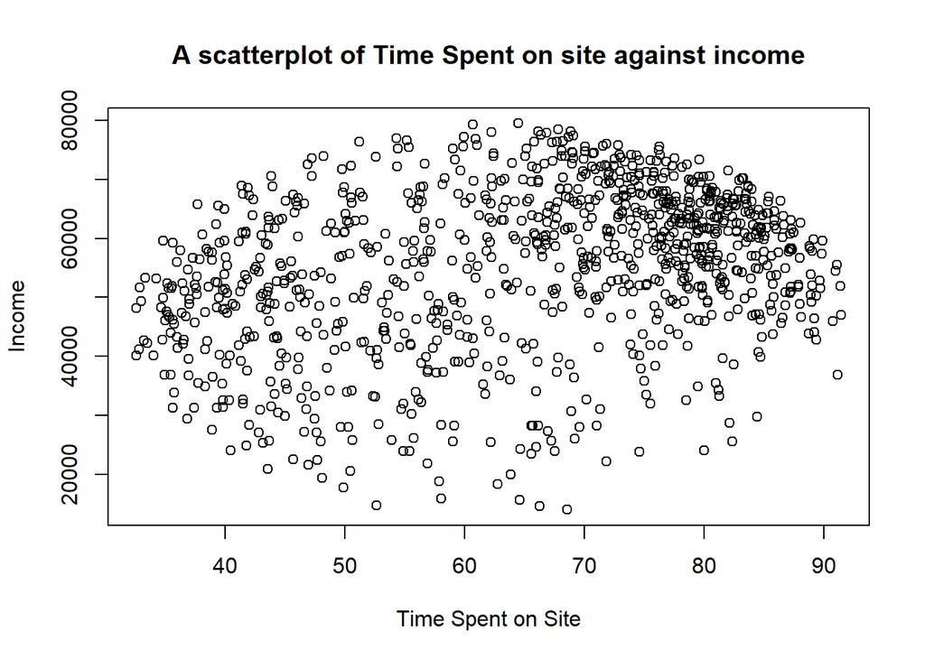

```r
# scatterplot of Time on site vs income
plot((ad$Daily_Time_Spent_on_Site), (ad$Area_Income),
     main = "A scatterplot of Time Spent on site against income",
     xlab = 'Time Spent on Site',
     ylab = 'Income')
```

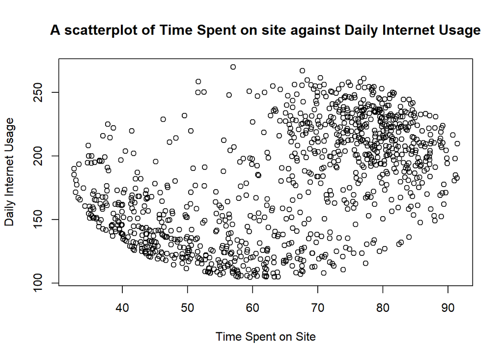

```r
# scatterplot of Time on site vs Internet usage
plot((ad$Daily_Time_Spent_on_Site), (ad$Daily_Internet_Usage),
     main = "A scatterplot of Time Spent on site against Daily Internet Usage",
     xlab = 'Time Spent on Site',
     ylab = 'Daily Internet Usage')
```

#### Heatmap

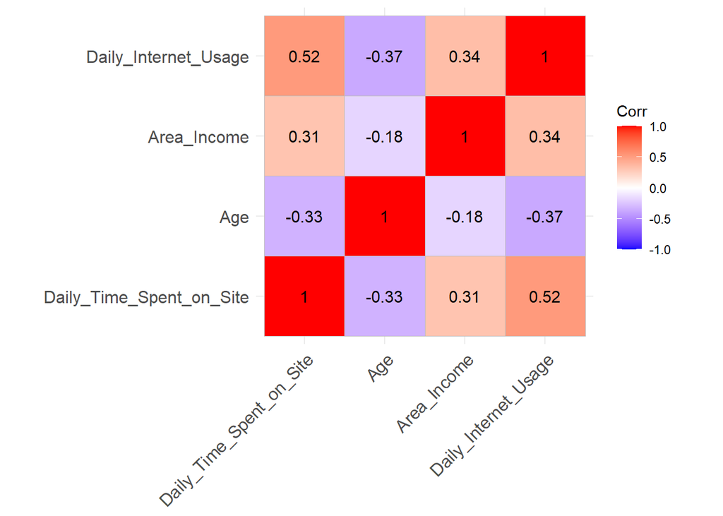

```r
# Heat map
# Checking the relationship between the variables
# Using Numeric variables only

numeric_tbl <- ad %>%
  select_if(is.numeric) %>%
  select(Daily_Time_Spent_on_Site, Age, Area_Income,Daily_Internet_Usage)

# Calculate the correlations
corr <- cor(numeric_tbl, use = "complete.obs")

ggcorrplot(round(corr, 2),
           type = "full", lab = T)
```

#### Those who clicked on ads:

Analysis of people who click on the ads:

```r
# Analysis of people who click on the ads
ad_click <- ad[which(ad$Clicked_on_Ad == 1),]
```

Most popular age group of people clicking on ads:

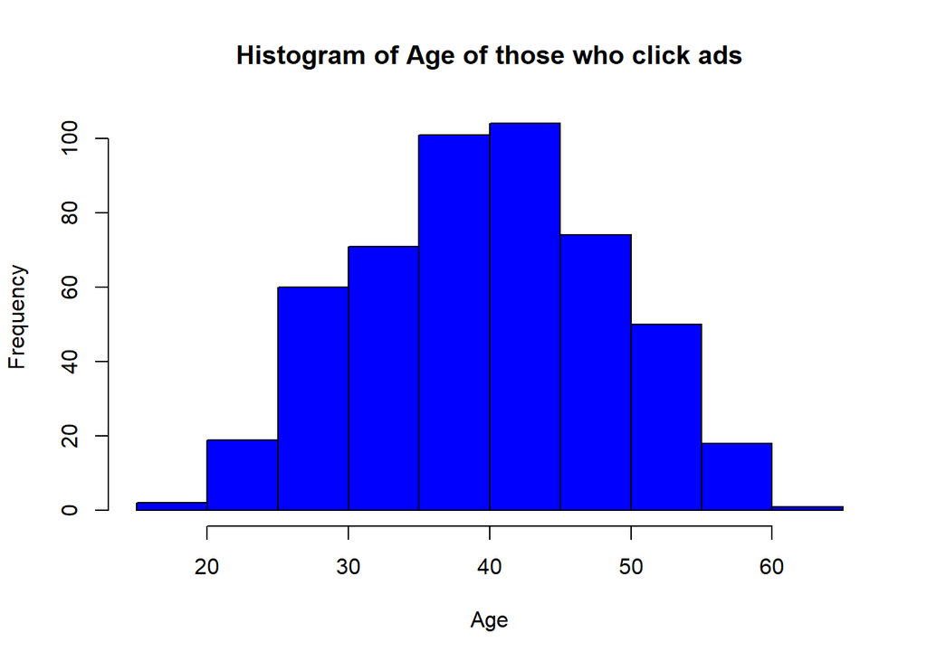

```r
# Most popular age group of people clicking on ads
hist((ad_click$Age),
     main = "Histogram of Age of those who click ads",
     xlab = 'Age',
     ylab = 'Frequency',
     col = "blue")
```

40 - 45 year olds click on the most ads

#### Plotting to visualize the gender distribution:

```r
gender2 <- (ad_click$Male)
gender2.frequency <- table(gender2)
gender2.frequency
```

```
## gender2
##   0   1
## 269 231
```

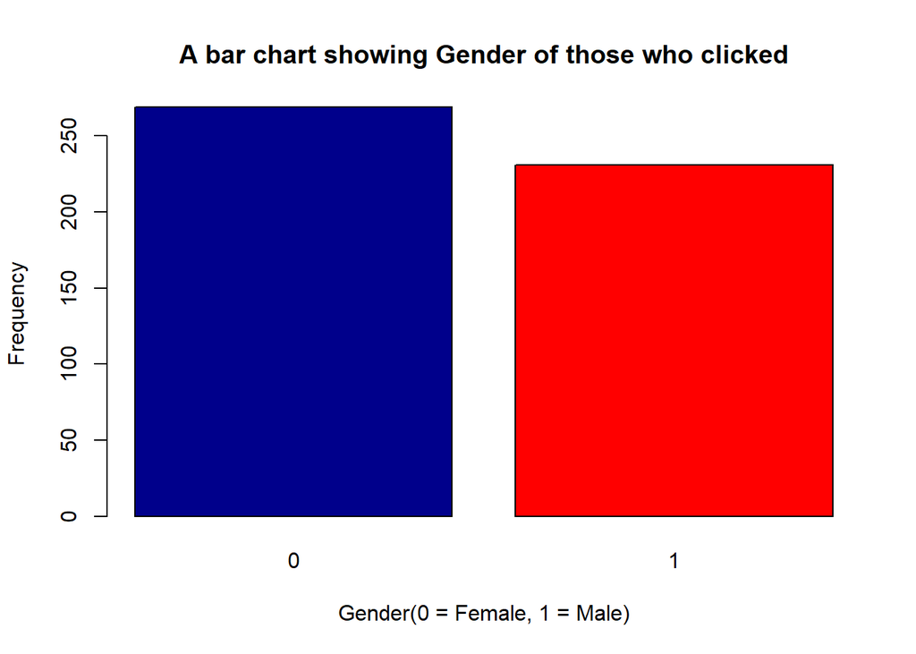

```r
# plotting to visualize the gender distribution

barplot(gender2.frequency,
  main="A bar chart showing Gender of those who clicked",
  xlab="Gender(0 = Female, 1 = Male)",
  ylab = "Frequency",
  col=c("darkblue","red"),
  )
```

Females clicked more ads than males.

#### Scatterplots of those who clicked:

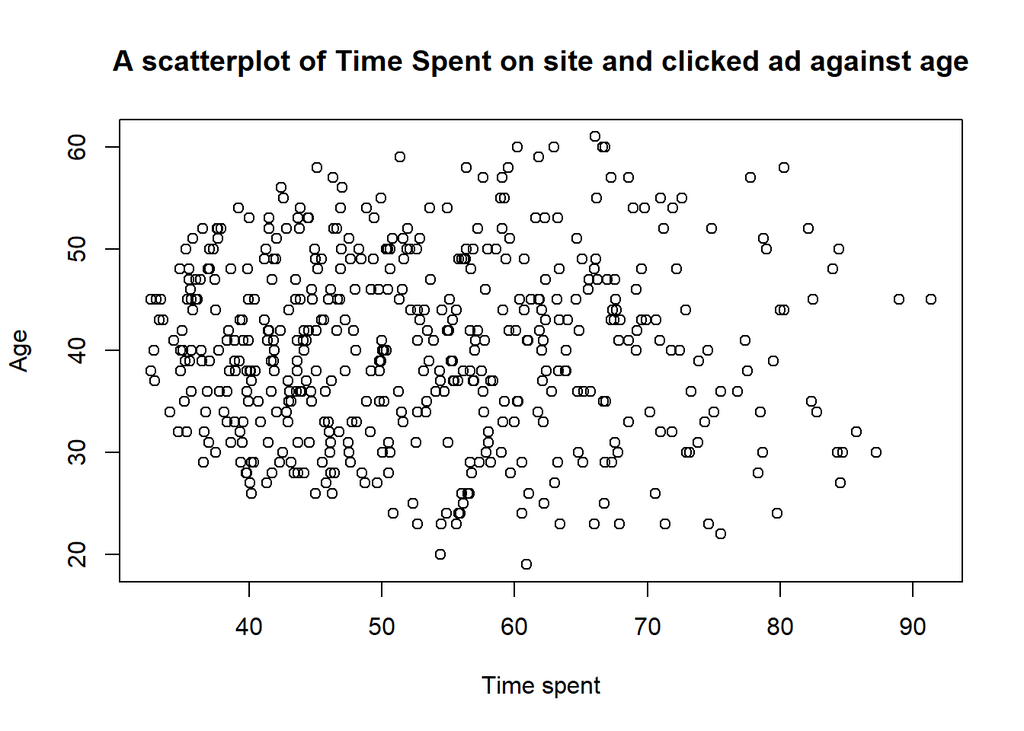

```r
# scatterplot
plot((ad_click$Daily_Time_Spent_on_Site), (ad_click$Age),
     main = "A scatterplot of Time Spent on site and clicked ad against age",
     xlab = 'Time spent',
     ylab = 'Age')
```

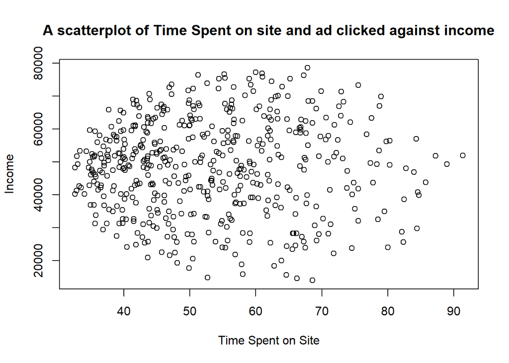

```r
# scatterplot of Time on site vs income
plot((ad_click$Daily_Time_Spent_on_Site), (ad_click$Area_Income),
     main = "A scatterplot of Time Spent on site and ad clicked against income",
     xlab = 'Time Spent on Site',
     ylab = 'Income')
```

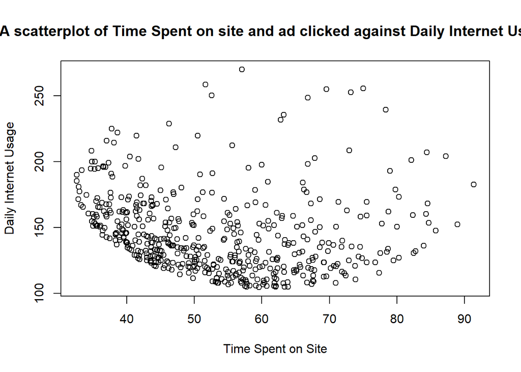

```r
# scatterplot of Time on site vs Internet usage
plot((ad_click$Daily_Time_Spent_on_Site), (ad_click$Daily_Internet_Usage),
     main = "A scatterplot of Time Spent on site and ad clicked against Daily Internet Usage",
     xlab = 'Time Spent on Site',
     ylab = 'Daily Internet Usage')
```

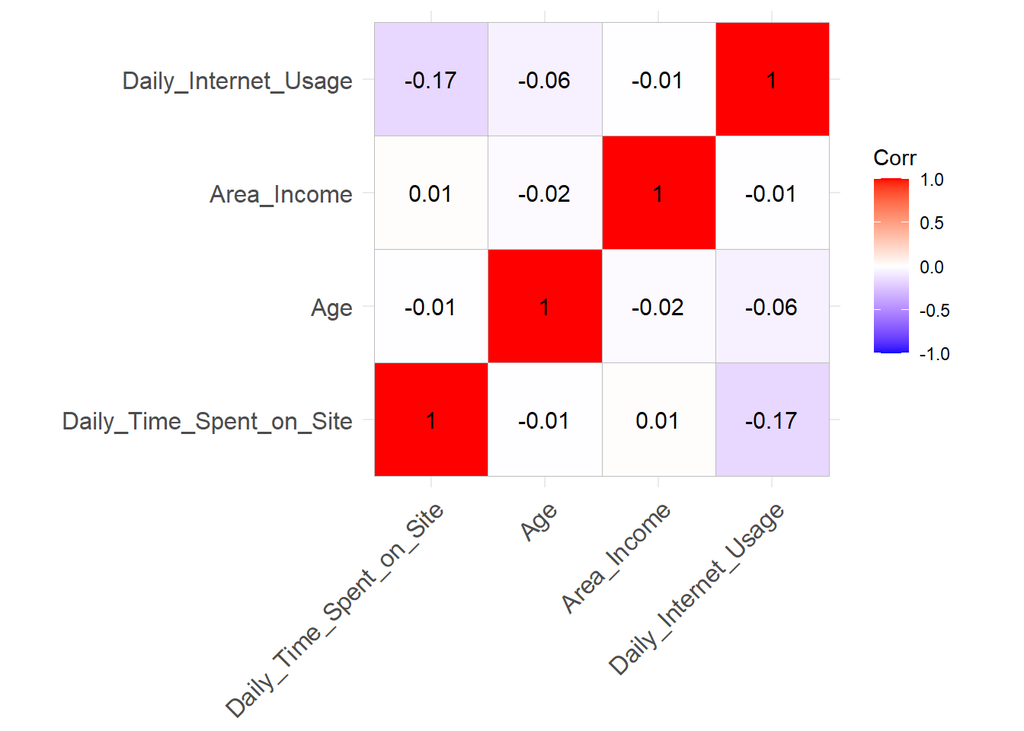

```r
# Heat map
# Checking the relationship between the variables
# Using Numeric variables only

numeric_tbl <- ad_click %>%
  select_if(is.numeric) %>%
  select(Daily_Time_Spent_on_Site, Age, Area_Income,Daily_Internet_Usage)

# Calculate the correlations
corr <- cor(numeric_tbl, use = "complete.obs")

ggcorrplot(round(corr, 2),
           type = "full", lab = T)
```

The country with the most ad clicks:

```r
mode(ad_click$Country)
```

```
## [1] "Australia"
```

The income that clicks most:

```r
mode(ad_click$Area_Income)
```

```
## [1] 24593.33
```

Ad title that garners most clicks:

```
## [1] "Reactive local challenge"
```

## 6. Conclusion

From the Exploratory Data Analysis, it can be concluded that those most likely to click on ads are Women from Australia, ranging from ages 40 - 45 and with an income of 24593. The ad title that is clicked on most is “Reactive local challenge”.

## 7. Recommendations

- There should be more locally targeted ads, seeing as the key word ‘local’ prompted more clicks.